```python
import numpy, scipy, matplotlib.pyplot as plt, pandas, librosa
```

← Back to Index

# Signal Representations

## Time Domain

The basic representation of an audio signal is in the *time domain*.

[Sound is air vibrating](https://en.wikipedia.org/wiki/Sound). An audio signal represents the fluctuation in air pressure caused by the vibration as a function of time.

Let's download and listen to a file:

```python
import urllib
urllib.urlretrieve('http://audio.musicinformationretrieval.com/c_strum.wav')

x, fs = librosa.load('c_strum.wav', sr=44100)

from IPython.display import Audio
Audio(x, rate=fs)
```

[interactive chart not shown]

To plot a signal in the time domain, use [`librosa.display.waveplot`](http://bmcfee.github.io/librosa/generated/librosa.display.waveplot.html):

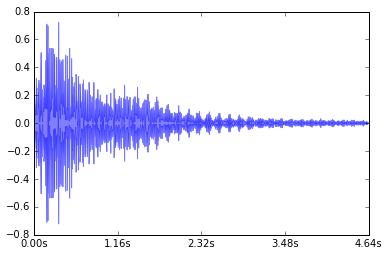

```python
librosa.display.waveplot(x, fs, alpha=0.5)
```

Let's zoom in:

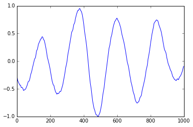

```python
plt.plot(x[8000:9000])
```

Digital computers can only capture this data at discrete moments in time. The rate at which a computer captures audio data is called the *sampling frequency* (abbreviated `fs`) or *sample rate* (abbreviated `sr`). For this workshop, we will mostly work with a sampling frequency of 44100 Hz.

## Fourier Transform

The *Fourier Transform* is one of the most fundamental operations in applied mathematics and signal processing.

It transforms our time-domain signal into the *frequency domain*. Whereas the time domain expresses our signal as a sequence of samples, the frequency domain expresses our signal as a *superposition of sinusoids* of varying magnitudes, frequencies, and phase offsets.

To compute a Fourier transform in NumPy or SciPy, use [`scipy.fft`](http://docs.scipy.org/doc/scipy/reference/generated/scipy.fftpack.fft.html#scipy.fftpack.fft):

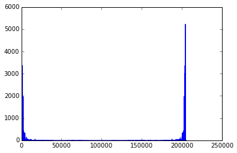

```python
X = scipy.fft(x)
X_mag = numpy.absolute(X)
plt.plot(X_mag) # magnitude spectrum
```

Zoom in:

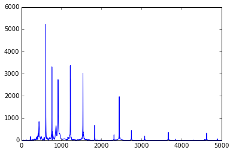

```python
plt.plot(X_mag[:5000])
```

In Essentia, you can also use [`essentia.standard.Spectrum`](http://essentia.upf.edu/documentation/reference/std_Spectrum.html) to compute a magnitude spectrum.

## Spectrogram

Musical signals are highly non-stationary, i.e., their statistics change over time. It would be rather meaningless to compute a spectrum over an entire 10-minute song.

Instead, we compute a spectrum for small frames of the audio signal. The resulting sequence of spectra is called a [*spectrogram*](https://en.wikipedia.org/wiki/Spectrogram).

### `matplotlib.specgram`

Matplotlib has [`specgram`](http://matplotlib.org/api/mlab_api.html#matplotlib.mlab.specgram) which computes and displays a spectrogram:

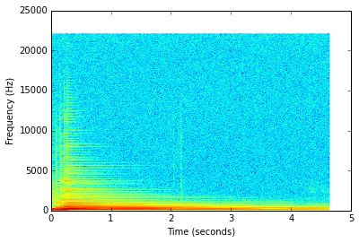

```python
S, freqs, bins, im = plt.specgram(x, NFFT=1024, noverlap=512, Fs=44100)
plt.xlabel('Time (seconds)')
plt.ylabel('Frequency (Hz)')
```

### `librosa.feature.melspectrogram`

`librosa` has some outstanding spectral representations, including [`librosa.feature.melspectrogram`](http://bmcfee.github.io/librosa/generated/librosa.feature.melspectrogram.html#librosa.feature.melspectrogram):

```python
S = librosa.feature.melspectrogram(x, sr=fs, n_fft=1024)
logS = librosa.logamplitude(S)
```

To display any type of spectrogram in librosa, use [`librosa.display.specshow`](http://bmcfee.github.io/librosa/generated/librosa.display.specshow.html):

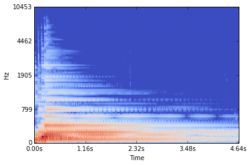

```python
librosa.display.specshow(logS, sr=fs, x_axis='time', y_axis='mel')
```

## Autocorrelation

The [autocorrelation](http://en.wikipedia.org/wiki/Autocorrelation) of a signal describes the similarity of a signal against a delayed version of itself.

Using [`numpy.correlate`](http://docs.scipy.org/doc/numpy/reference/generated/numpy.correlate.html):

```
(204800,) (204800,)
```

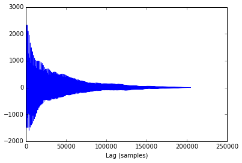

```python
# Because the autocorrelation produces a symmetric signal, we only care about the "right half".
r = numpy.correlate(x, x, mode='full')[len(x)-1:]
print x.shape, r.shape
plt.plot(r)
plt.xlabel('Lag (samples)')
```

Using [`essentia.standard.AutoCorrelation`](http://essentia.upf.edu/documentation/reference/std_AutoCorrelation.html):

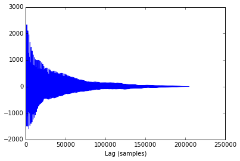

```python
from essentia.standard import AutoCorrelation
autocorr = AutoCorrelation()
r = autocorr(x)
plt.plot(r)
plt.xlabel('Lag (samples)')
```

## `librosa.cqt`

Unlike the Fourier transform, the [constant-Q transform](http://en.wikipedia.org/wiki/Constant_Q_transform) uses a logarithmically spaced frequency axis.

To plot a constant-Q spectrogram, will use [`librosa.cqt`](http://bmcfee.github.io/librosa/generated/librosa.core.cqt.html#librosa.core.cqt):

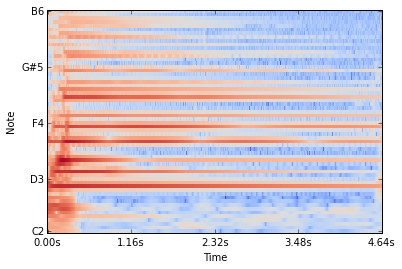

```python
fmin = librosa.midi_to_hz(36)
C = librosa.cqt(x, sr=fs, fmin=fmin, n_bins=60)
logC = librosa.logamplitude(C)
librosa.display.specshow(logC, sr=fs, x_axis='time', y_axis='cqt_note', fmin=fmin, cmap='coolwarm')
```

← Back to Index